# Enrollment by School, Grade: 2018-19 to 2021-22

## Deliverable 1: Excel file

Will be sent as a file attachment.

## Deliverable 2: Code to generate work products

Click “Show code” to see underlying calculations.

Repository available at: https://github.com/stevenprimeaux/dcps.

### Import

Load required packages.

```r
library(tidyverse)
library(readxl)
library(writexl)
library(janitor)
```

Download files and save with standardized names in project directory.

```r
url_prefix <- paste0(
  "https://osse.dc.gov/",
  "sites/default/files/dc/sites/osse/page_content/attachments/"
)

download.file(
  paste0(
    url_prefix,
    "2018-19%20School%20Year%20Annual%20Enrollment%20Audit%20Report%20Supplemental%20Tables.xlsx"
  ),
  destfile = "enrollment_2019.xlsx", mode = "wb", quiet = TRUE
)

download.file(
  paste0(
    url_prefix,
    "SY21-22%20Annual%20Enrollment%20Audit%20Supplemental%20Tables_02082022.xlsx"
  ),
  destfile = "enrollment_2022.xlsx", mode = "wb", quiet = TRUE
)
```

Read in downloaded files and standardize column names.

Initially read all columns as text to avoid guessing column types. Explicit type conversions will be applied later.

```r
enrollment_2019_raw <-
  read_excel(
    "enrollment_2019.xlsx",
    sheet = "School Audited Enr by Grade",
    range = "A1:V487",
    col_types = "text"
  ) |>
  clean_names()

enrollment_2022_raw <-
  read_excel(
    "enrollment_2022.xlsx",
    sheet = "School Audited Enr by Grade",
    range = "A1:F2334",
    col_types = "text"
  ) |>
  clean_names()
```

### Tidying and Transformation

Specify vector of clean grade levels for standardizing across years.

```r
levels_grade <- c(
  "total",
  "pk3", "pk4",
  "kg", "1", "2", "3", "4", "5", "6", "7", "8",
  "9", "10", "11", "12",
  "adult", "ungraded"
)

grades_high <- c("9", "10", "11", "12")
```

Clean up 2019 table and add identifier for year.

Observe that 2019 file presents the data in a denormalized or “wide” format, such that each grade is a separate column, while the 2022 file presents the data in a normalized or “long” format, such that grade is a variable in a single column.

Pivot 2019 table into long format to allow for tidy data operations.

Standardize grade variable.

```r
enrollment_2019 <-
  enrollment_2019_raw |>
  pivot_longer(
    cols = audited_enrollment:ungraded,
    names_to = "grade",
    values_to = "n_enrolled"
  ) |>
  mutate(across(grade, \(x) str_to_lower(x))) |>
  mutate(across(grade, \(x) str_remove(x, "^x0"))) |>
  mutate(across(grade, \(x) str_remove(x, "^x"))) |>
  mutate(across(grade, \(x) str_trim(x))) |>
  mutate(grade = if_else(grade == "audited_enrollment", "total", grade)) |>
  mutate(grade = factor(grade, levels = levels_grade)) |>
  mutate(year = 2019, .before = 0)
```

Clean up 2022 table and add identifier for year.

Standardize grade variable.

```r
enrollment_2022 <-
  enrollment_2022_raw |>
  rename(n_enrolled = enrolled) |>
  mutate(across(grade, \(x) str_to_lower(x))) |>
  mutate(across(grade, \(x) str_remove(x, "grade "))) |>
  mutate(across(grade, \(x) str_remove(x, " enrolled"))) |>
  mutate(across(grade, \(x) str_trim(x))) |>
  mutate(grade = factor(grade, levels = levels_grade)) |>
  mutate(year = 2022, .before = 0)
```

Stack 1-year tables into single multi-year table for tidy data operations.

Clean up LEA codes.

Filter for DCPS and relevant grades.

```r
enrollment <-
  bind_rows(enrollment_2019, enrollment_2022) |>
  mutate(across(n_enrolled, as.numeric)) |>
  mutate(
    across(lea_code, \(x) str_pad(x, width = 3, side = "left", pad = "0"))
  ) |>
  filter(lea_code == "001", grade %in% grades_high) |>
  arrange(year, school_name, grade)
```

Validate grades.

```r
enrollment |> count(year, grade)
```

```
# A tibble: 8 × 3
   year grade     n
  <dbl> <fct> <int>
1  2019 9       174
2  2019 10      174
3  2019 11      174
4  2019 12      174
5  2022 9        55
6  2022 10       42
7  2022 11       37
8  2022 12       48
```

Observe that no students were classified as ungraded in the 2022 data.

Check for school codes and names that are inconsistent across the two years.

```r
enrollment |>
  distinct(school_code, school_name) |>
  count(school_name, sort = TRUE) |>
  filter(n > 1)
```

```
# A tibble: 0 × 2
# ℹ 2 variables: school_name <chr>, n <int>
```

```r
name_changed <-
  enrollment |>
  distinct(school_code, school_name) |>
  count(school_code, sort = TRUE) |>
  filter(n > 1) |>
  left_join(enrollment, by = join_by(school_code)) |>
  distinct(school_code, school_name, year) |>
  arrange(school_code, school_name, year)

name_changed
```

```
# A tibble: 12 × 3
   school_code school_name                                  year
   <chr>       <chr>                                       <dbl>
 1 1050        Chelsea School                               2022
 2 1050        Chelsea School Hyattsville MD                2019
 3 1087        Forbush School at Glyndon Reisterstown MD    2019
 4 1087        Sheppard Pratt School-Glyndon                2022
 5 1159        Pathways Horizons                            2022
 6 1159        The Pathways School Northwood                2019
 7 3005        Forbush at Oakmont- Upper School             2019
 8 3005        Sheppard Pratt School-Gaithersburg           2022
 9 3033        Frost School Oakmont Program Rockville MD    2019
10 3033        Sheppard Pratt School-Rockville              2022
11 3115        Sheppard Pratt School-Lanham                 2022
12 3115        The Forbush School at Prince Georges County  2019
```

```r
name_changed_lookup <-
  name_changed |>
  filter(year == 2022) |>
  select(school_code, school_name_recent = school_name)
```

No schools kept the same name while changing school codes, but a few schools changed names while keeping the same school code. Use the more recent name for convenience.

Create rows for DCPS overall by grade and bind back to table for helpful reference during exploratory analysis.

Shorten school names for better plotting.

```r
dc_overall <-
  enrollment |>
  group_by(lea_code, lea_name, year, grade) |>
  summarize(n_enrolled = sum(n_enrolled)) |>
  mutate(school_code = lea_code, school_name = lea_name)

enrollment_clean <-
  enrollment |>
  left_join(name_changed_lookup, by = join_by(school_code)) |>
  mutate(
    school_name = if_else(
      !is.na(school_name_recent), school_name_recent, school_name
    ),
    school_name = str_remove(school_name, "High School$|Campus$")
  ) |>
  select(!school_name_recent) |>
  bind_rows(dc_overall)
```

Verify inconsistent names have been fixed.

```r
enrollment_clean |>
  distinct(school_code, school_name) |>
  count(school_code, sort = TRUE) |>
  filter(n > 1)
```

```
# A tibble: 0 × 2
# ℹ 2 variables: school_code <chr>, n <int>
```

Pivot enrollment count columns back out to wide format so each school-grade pair can be displayed with both years on a single row.

In calculations for change over time, school-grades that did not have at least 10 students in both years are excluded because the rate of change will often be infinite, bounded at negative 100 percent, or related to an alternative school arrangement.

Create rows for DCPS median by grade, which will provide the context needed to answer the request. In other words, is the median across schools consistent with the overall change for that grade, or do they diverge?

```r
enrollment_yoy <-
  enrollment_clean |>
  pivot_wider(
    names_from = year, values_from = n_enrolled, names_prefix = "n_enrolled_"
  ) |>
  mutate(across(starts_with("n_enrolled"), \(x) replace_na(x, 0))) |>
  mutate(
    n_enrolled_change = n_enrolled_2022 - n_enrolled_2019,
    rate_enrolled_change = round(n_enrolled_change / n_enrolled_2019, 3)
  ) |>
  mutate(
    school_name = if_else(school_code == "001", "Overall", school_name)
  ) |>
  filter(n_enrolled_2019 >= 10 & n_enrolled_2022 >= 10) |>
  select(!c(lea_code, lea_name))

dc_summary <-
  enrollment_yoy |>
  filter(school_code != "001") |>
  group_by(grade) |>
  summarize(
    rate_enrolled_change = round(median(rate_enrolled_change), 3)
  ) |>
  mutate(school_name = "Median")

enrollment_yoy <-
  enrollment_yoy |>
  bind_rows(dc_summary) |>
  mutate(
    color_fill = if_else(
      school_name %in% c("Overall", "Median"), "black", "darkgray"
    )
  )
```

```r
yoy <-
  enrollment_yoy |>
  mutate(school_name = fct_relevel(school_name, c("Overall", "Median"))) |>
  select(!color_fill) |>
  arrange(school_name, grade)

write_xlsx(
  list("Enrollment YOY" = yoy, "Enrollment Long" = enrollment_clean),
  path = "Deliverable 1.xlsx"
)
```

### Exploratory Analysis

#### Overall by Grade

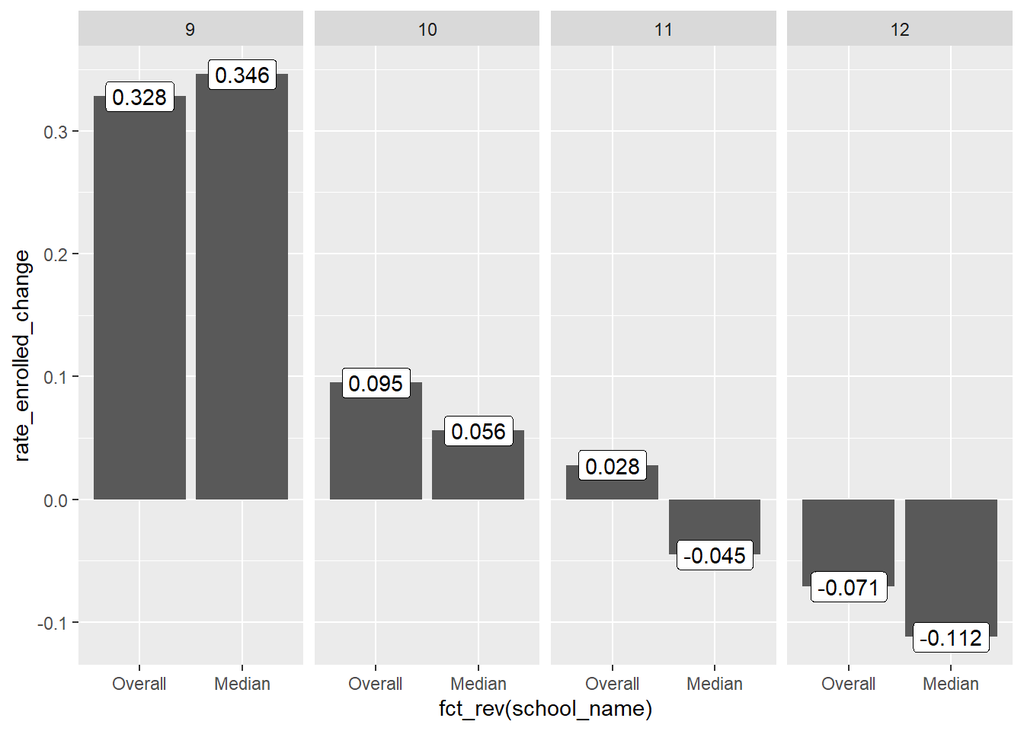

```r
enrollment_yoy |>
  filter(str_detect(school_name, "Overall|Median")) |>
  ggplot(
    aes(
      x = fct_rev(school_name),
      y = rate_enrolled_change,
    )
  ) +
  geom_col() +
  geom_label(aes(label = rate_enrolled_change)) +
  facet_wrap(vars(grade), ncol = 4)
```

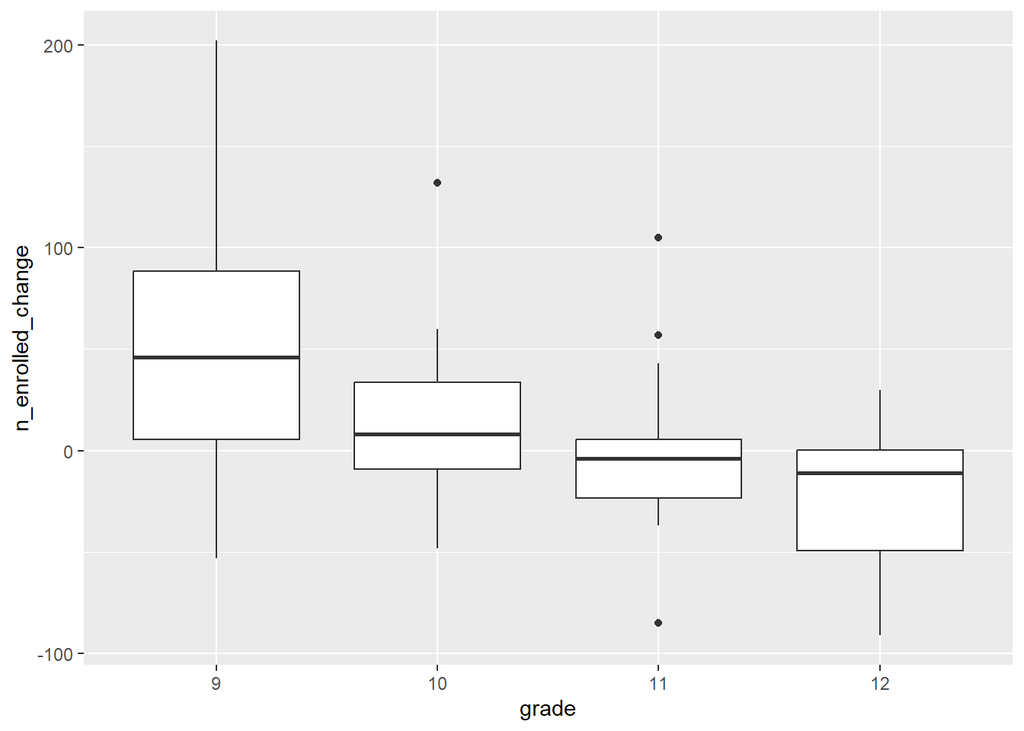

```r
enrollment_yoy |>
  filter(!str_detect(school_name, "Overall|Median")) |>
  ggplot(aes(x = grade, y = n_enrolled_change)) +
  geom_boxplot()
```

#### Individual Schools

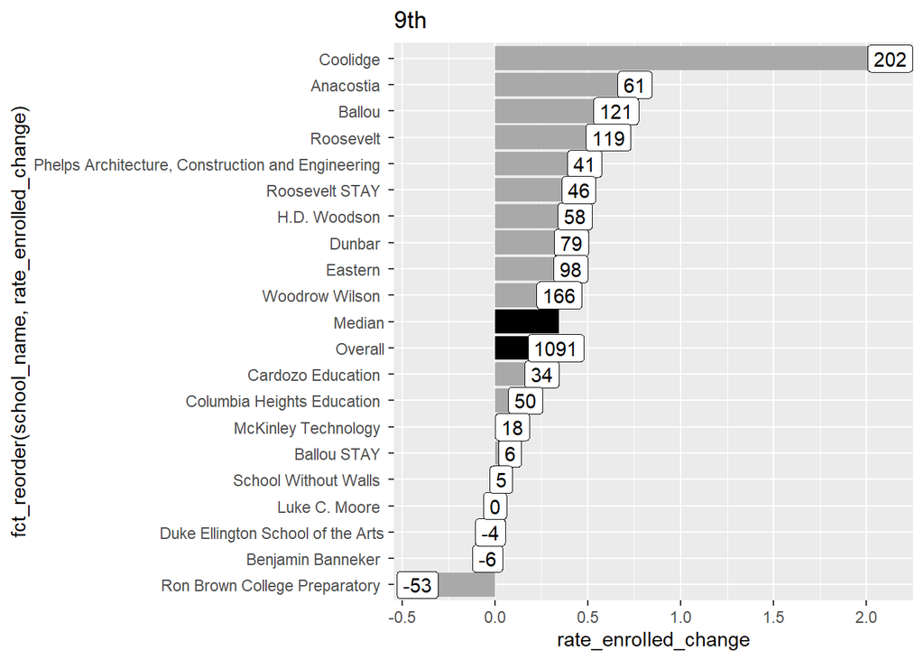

```r
enrollment_yoy |>
  filter(grade == "9") |>
  ggplot(
    aes(
      x = rate_enrolled_change,
      y = fct_reorder(school_name, rate_enrolled_change),
      label = n_enrolled_change
    )
  ) +
  geom_col(aes(fill = color_fill)) +
  geom_label() +
  scale_fill_identity() +
  ggtitle("9th")
```

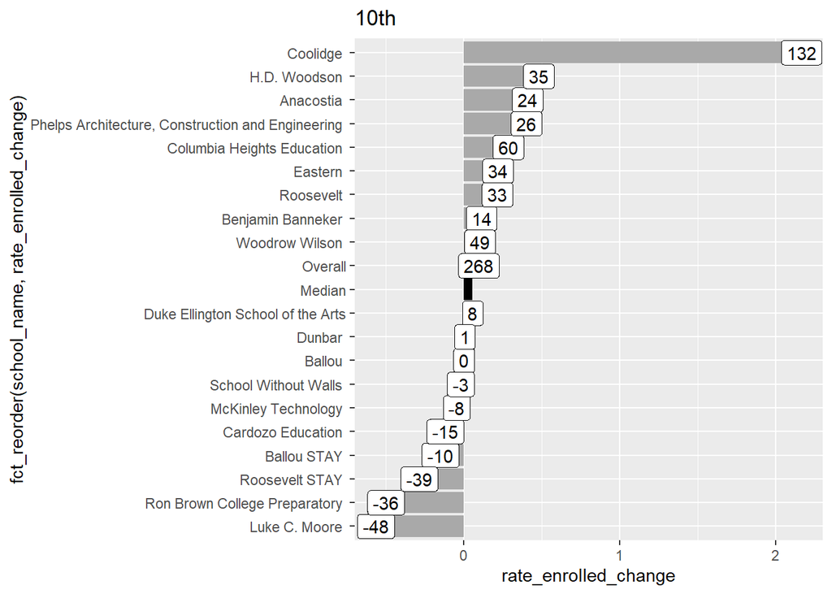

```r
enrollment_yoy |>
  filter(grade == "10") |>
  ggplot(
    aes(
      x = rate_enrolled_change,
      y = fct_reorder(school_name, rate_enrolled_change),
      label = n_enrolled_change
    )
  ) +
  geom_col(aes(fill = color_fill)) +
  geom_label() +
  scale_fill_identity() +
  ggtitle("10th")
```

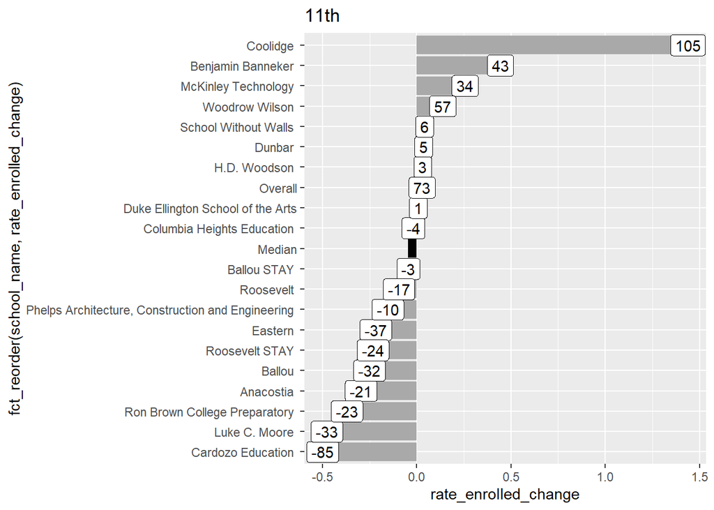

```r
enrollment_yoy |>
  filter(grade == "11") |>
  ggplot(
    aes(
      x = rate_enrolled_change,
      y = fct_reorder(school_name, rate_enrolled_change),
      label = n_enrolled_change
    )
  ) +
  geom_col(aes(fill = color_fill)) +
  geom_label() +
  scale_fill_identity() +
  ggtitle("11th")
```

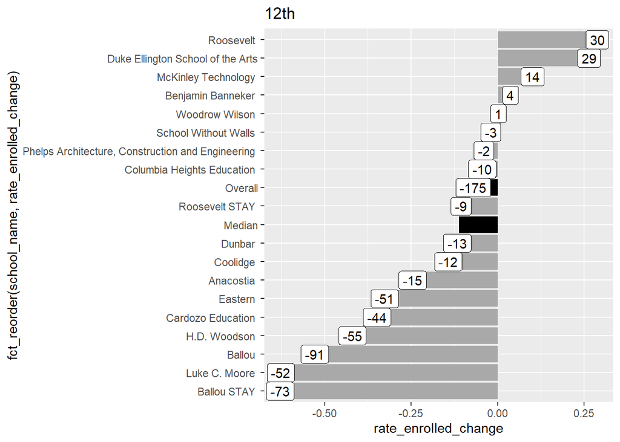

```r
enrollment_yoy |>
  filter(grade == "12") |>
  ggplot(
    aes(
      x = rate_enrolled_change,
      y = fct_reorder(school_name, rate_enrolled_change),
      label = n_enrolled_change
    )
  ) +
  geom_col(aes(fill = color_fill)) +
  geom_label() +
  scale_fill_identity() +
  ggtitle("12th")
```

```r
counts_increasing <-
  enrollment_yoy |>
  group_by(grade) |>
  summarize(
    n_schools = n(),
    n_increase = sum(n_enrolled_change > 0, na.rm = TRUE),
    perc_increase = round(n_increase / n_schools, 3) * 100
  )
```

## Deliverable 3: Email

Dear Mr. Brown:

Thanks so much for digging into those high school enrollment numbers, especially with many large districts around the country grappling with declining enrollment.

I’ve attached the full supporting data by school and grade, but please find below a summary table that should help to answer the question of whether the overall change by grade was evenly distributed across schools.

| Grade | Change # Students | % Change Overall | Median % Change | # Schools | # Increasing | % Increasing |
| --- | --- | --- | --- | --- | --- | --- |
| 9 | 1091 | 32.8 | 34.6 | 21 | 16 | 76.2 |
| 10 | 268 | 9.5 | 5.6 | 21 | 12 | 57.1 |
| 11 | 73 | 2.8 | -4.5 | 21 | 9 | 42.9 |
| 12 | -175 | -7.1 | -11.2 | 20 | 5 | 25.0 |

Like you said, 9th grade saw a net increase of 1,091 students overall (33 percent) during this period, and the median increase across schools with at least 10 students enrolled in both years was 35 percent. 10th grade had an increase of 268 students (10 percent), with a median increase by school of 6 percent. 16 schools added students in 9th grade, and 12 schools added students in 10th grade.

With 11th grade on the other hand, the small net increase of 73 students overall (3 percent) was driven primarily by adding 105 students at Coolidge. The median change across schools was actually a decrease of around -5 percent, and only 9 schools added students.

12th grade showed a broad-based decline of -175 students overall (-7 percent), which follows a median decline of -11 percent across schools, where 15 of 20 lost students over this period. Note that Ron Brown College Prep was excluded for 12th grade because they were building out from zero to 52 students over this period.

As far as figuring out how many of these students are reported in the same grade in both periods, I don’t have that data readily available, but I’ve started working on a query to pull that information from our system.

Please let me know if you need anything else on these enrollment figures, and I’ll be happy to assist!

–Steven

## Deliverable 4: Students in same grade

This calculation is actually something that I’ve built at NOLA Public Schools, so the basic rules are very familiar. The pseudocode looks something like this:

Let annual_enrollment_detail be a database table of year-student-school-grade tuples. Let years be an array of years from 2018 to 2021.

For year in years:

Let tbl_year1 = annual_enrollment_detail filtered for audit_year == year (2018 for example). Let tbl_year2 = annual_enrollment_detail filtered for audit_year == year + 1 (2019 for example).

Left join tbl_year2 back onto tbl_year1 using student_id, school_code, and grade_level. (If you don’t care whether they changed schools, use student and grade only.)

The records in tbl_year1 with a successful join are those students that were not promoted, subject to any other filters or business rules.

As a proportion, the first year is the denominator and the number of successful joins in the second year is the numerator, but you could also flip the calculation and work backward, using year as the denominator and any successful joins against year - 1 as the numerator.